# Numpy_basic

## 1. Numpy 란?

### 1.1 파이썬 과학 처리 패키지

- Numerical Python
- 파이썬의 고성능 과학 계산용 패키지
- Matrix와 Vector와 같은 Array 연산의 사실상의 표준

### 1.2 특징

- 일반 List에 비해 빠르고, 메모리를 효율적으로 사용
- 반복문 없이 데이터 배열에 대한 처리를 지원함
- 선형대수와 관련된 다양한 기능을 제공
- C, C++등의 언어와 통합 가능

## 2. ndarray(Numpy Dimensional Array)

### 2.1 import

```python
import numpy as np  # np는 표준화된 이름
```

### 2.2 Array 생성

- numpy는 np.array 함수를 활용하여 배열을 생성함 -> ndarray
- numpy는 하나의 데이터 타입만 배열에 넣을 수 있음
- List와 가장 큰 차이점은, 다양한 형태의 데이터 타입을 지원하지 않음. (대신 처리 속도가 빠름)
- C의 array를 사용하여 배열을 생성하기 때문에 속도 측면에서 강점을 보임 (복잡한 계산을 빠르게 처리)

```python
test_array = np.array([1, 4, 5, 8], float)
print(test_array)
```

```
[1. 4. 5. 8.]
```

```python
type(test_array[3])
print(test_array.dtype)  # Array 전체의 데이터 타입을 반환함
```

```
float64
```

```python
print(test_array.shape)  # Array의 shape(차원 구성)을 반환함
```

```
(4,)
```

## 3. Array shape

### 3.1 Vector (1차원)

```python
test_array = np.array([1, 4, 5, 8], float)  # shape는 (4,) : 1차원에 4개의 요소가 있는 벡터
np.array(test_array, int).shape
```

```
(4,)
```

### 3.2 Matirx (2차원)

```python
matrix = [[1,2,5,8], [2,3,4,9], [4,5,6,7]]
np.array(matrix, int).shape  # shape는 (3, 4) : 행이 3개, 열이 4개인 매트릭스
```

```
(3, 4)
```

### 3.3 Tensor (3차원)

```python
tensor = [[[1,2,5,8], [2,3,4,9], [4,5,6,7]],
          [[1,2,5,8], [2,3,4,9], [4,5,6,7]],
          [[1,2,5,8], [2,3,4,9], [4,5,6,7]],
          [[1,2,5,8], [2,3,4,9], [4,5,6,7]]]
np.array(tensor, int).shape  # shape는 (4, 3, 4) : 평면이 4개, 행이 3개, 열이 4개인 텐서
```

```
(4, 3, 4)
```

### 3.4 ndim & size

```python
np.array(tensor, int).ndim  # 3차원
```

```
3
```

```python
np. array(tensor, int).size  # 48개의 요소
```

```
48
```

### 3.5 dtype

- single element가 가지는 데이터 타입
- C의 데이터 타입과 호환
- nbyte - ndarray object의 메모리 크기를 바이트 단위로 반환함

```python
np.array([[1,2,3], [4.5, '5', '6']], dtype = np.float32)  # 실수 타입으로 변경
```

```
array([[1. , 2. , 3. ],
       [4.5, 5. , 6. ]], dtype=float32)
```

### 3.6 reshape

- Array의 shape를 변경함 (element의 개수는 동일)

```python
test_matrix = [[1,2,3,4], [5,6,7,8]]
np.array(test_matrix).shape
```

```
(2, 4)
```

```python
np.array(test_matrix).reshape(8,)  # 요소의 갯수가 8개인 1차원 벡터로 만들어라.
```

```
array([1, 2, 3, 4, 5, 6, 7, 8])
```

```python
np.array(test_matrix).reshape(8,).shape  # 변경된 벡터의 모양 확인
```

```
(8,)
```

- Array의 Size만 같다면, 다차원으로 자유롭게 변경이 가능함

```python
np.array(test_matrix).reshape(-1, 2)  # -1 : size를 기반으로 row 개수를 알아서 선정
```

```
array([[1, 2],
       [3, 4],
       [5, 6],
       [7, 8]])
```

```python
print(np.array(test_matrix).reshape(-1, 2).shape) # 변경 후 모양 확인
```

[output not shown]

```python
print(np.array(test_matrix).reshape(2, 2, 2))  # 요소의 갯수만 맞다면 다양한 차원으로 생성 가능
```

```
[[[1 2]
  [3 4]]

 [[5 6]
  [7 8]]]
```

### 3.6 flatten

```python
test_matrix = [[[1,2,3,4], [5,6,7,8]], [[2,3,4,5], [6,7,8,9]]]  # 3차원, (2,2,4)
```

```python
print(np.array(test_matrix).shape)
```

```
(2, 2, 4)
```

```python
print(np.array(test_matrix).flatten())  # 다차원 array를 1차원 array로 변환
```

```
[1 2 3 4 5 6 7 8 2 3 4 5 6 7 8 9]
```

## 4. Indexing & slicing

### 4.1 Indexing

- List와 달리 2차원 배열에서 [0,0]과 같은 표기법을 제공함
- Matrix일 경우 앞은 행(row), 뒤는 열(column)을 의미함

```python
a = np.array([[1,2,3], [4,5,6]], int)
print(a)
```

```
[[1 2 3]
 [4 5 6]]
```

```python
print(a[0,0])  # 2차원 배열 표기법 1
```

```
1
```

```python
print(a[0][0])  # 2차원 배열 표기법 2
```

```
1
```

### 4.2 Slicing

- List와 달리 행과 열 부분을 나눠서 Slicing이 가능함.
- Matrix의 부분 집합을 추출할 때 유용함

```python
b = np.array([[1,2,3,4,5], [6,7,8,9,10]])
print(b)
```

```
[[ 1  2  3  4  5]
 [ 6  7  8  9 10]]
```

```python
print(b[:, 2:])  # row 전체, col 2 부터
```

```
[[ 3  4  5]
 [ 8  9 10]]
```

```python
print(b[1, 1:3])  # row 1, col 1~3
```

```
[7 8]
```

```python
print(b[1:3])  # row 1 ~ row 2 전체, col은 무시
```

```
[[ 6  7  8  9 10]]
```

```python
print(b[:, ::2])  # row 전체, col은 2칸씩 띄우기
```

```
[[ 1  3  5]
 [ 6  8 10]]
```

## 5. Creation function

### 5.1 arange

```python
print(np.arange(10))  # range(10)과 같음.
```

```
[0 1 2 3 4 5 6 7 8 9]
```

```python
print(np.arange(0, 5, 0.5))  # floating point도 표시가능 (소수점 뒤 0은 생략)
```

```
[0.  0.5 1.  1.5 2.  2.5 3.  3.5 4.  4.5]
```

```python
print(np.arange(0, 5, 0.5).tolist())  # list로 만들 수 있음
```

```
[0.0, 0.5, 1.0, 1.5, 2.0, 2.5, 3.0, 3.5, 4.0, 4.5]
```

```python
print(np.arange(30).reshape(5, 6))  # size가 같으면 가능
```

```
[[ 0  1  2  3  4  5]
 [ 6  7  8  9 10 11]
 [12 13 14 15 16 17]
 [18 19 20 21 22 23]
 [24 25 26 27 28 29]]
```

### 5.2 ones, zeros and empty

```python
print(np.zeros(shape=(10,), dtype=np.int8))  # 값이 0인 벡터 10개 생성
```

```
[0 0 0 0 0 0 0 0 0 0]
```

```python
print(np.ones((2, 5)))  # 값이 1인 2 x 5 matrix 생성
```

```
[[1. 1. 1. 1. 1.]
 [1. 1. 1. 1. 1.]]
```

```python
print(np.empty((3, 5)))  # shape만 생성하고, 값은 비어있는 ndarray 생성
```

```
[[1.59e-321 0.00e+000 0.00e+000 0.00e+000 0.00e+000]
 [0.00e+000 0.00e+000 0.00e+000 0.00e+000 0.00e+000]
 [0.00e+000 0.00e+000 0.00e+000 0.00e+000 0.00e+000]]
```

### 5.3 Something like

```python
test_matrix = np.arange(30).reshape(5,6)
print(test_matrix)
```

```
[[ 0  1  2  3  4  5]
 [ 6  7  8  9 10 11]
 [12 13 14 15 16 17]
 [18 19 20 21 22 23]
 [24 25 26 27 28 29]]
```

```python
print(np.ones_like(test_matrix))  # 기존 matrix의 모양으로 값을 변경(1)
```

```
[[1 1 1 1 1 1]
 [1 1 1 1 1 1]
 [1 1 1 1 1 1]
 [1 1 1 1 1 1]
 [1 1 1 1 1 1]]
```

```python
print(np.zeros_like(test_matrix))  # 기존 matrix의 모양으로 값을 변경 (0)
```

```
[[0 0 0 0 0 0]
 [0 0 0 0 0 0]
 [0 0 0 0 0 0]
 [0 0 0 0 0 0]
 [0 0 0 0 0 0]]
```

### 5.4 identity (단위 행렬 생성)

- 다른 행렬과 곱해도 다른행렬이 그대로 나오게 하는 행렬
- `2 x 1`에서의 1과 같음
- 정사각형 형태만 만들 수 있음(변수가 1개, n)

```python
print(np.identity(n=3, dtype=np.int8))  # n : number of rows, 정수 형태
```

```
[[1 0 0]
 [0 1 0]
 [0 0 1]]
```

```python
print(np.identity(5))
```

```
[[1. 0. 0. 0. 0.]
 [0. 1. 0. 0. 0.]
 [0. 0. 1. 0. 0.]
 [0. 0. 0. 1. 0.]
 [0. 0. 0. 0. 1.]]
```

### 5.5 eye (대각선이 1인 행렬)

- `identity`와 차이점은 대각선 시작위치(k)를 정할 수 있음
- 정사각형 형태 뿐만 아니라, 다양한 행렬을 생성할 수 있음 (변수가 2개, N, M)

```python
print(np.eye(N=3, M=5, dtype=np.int8))  # N, M은 대문자로
```

```
[[1 0 0 0 0]
 [0 1 0 0 0]
 [0 0 1 0 0]]
```

```python
print(np.eye(5)) # 실수 형태
```

```
[[1. 0. 0. 0. 0.]
 [0. 1. 0. 0. 0.]
 [0. 0. 1. 0. 0.]
 [0. 0. 0. 1. 0.]
 [0. 0. 0. 0. 1.]]
```

```python
print(np.eye(3, 5, k=2))  # 3 row, 5 col, k : start index
```

```
[[0. 0. 1. 0. 0.]
 [0. 0. 0. 1. 0.]
 [0. 0. 0. 0. 1.]]
```

```python
print(np.eye(5, 4, k=3))
```

```
[[0. 0. 0. 1.]
 [0. 0. 0. 0.]
 [0. 0. 0. 0.]
 [0. 0. 0. 0.]
 [0. 0. 0. 0.]]
```

### 5.6 diag (대각 행렬의 값을 추출)

```python
matrix = np.arange(9).reshape(3, 3)
print(matrix)
```

```
[[0 1 2]
 [3 4 5]
 [6 7 8]]
```

```python
print(np.diag(matrix))  # 생성되어 있는 matrix의 대각 행렬의 값을 반환
```

```
[0 4 8]
```

```python
print(np.diag(matrix, k=1))  # 대각선 시작위치(k)를 통해 원하는 대각선을 반환
```

```
[1 5]
```

### 5.7 Random Sampling (데이터 분포에 따른 샘플링으로 배열 생성)

```python
np.random.seed(seed=1000)  # seed로 생성 초기값 지정
```

```python
print(np.random.uniform(0, 1, 10).reshape(2, 5))  # 균등분포, 최소 0, 최대 1, 10개, 2 x 5 행렬 생성
```

```
[[0.20708234 0.74246953 0.39215413 0.18225652 0.74353941]
 [0.06958208 0.8853372  0.9526444  0.93114343 0.41543095]]
```

```python
print(np.random.normal(0, 1, 10).reshape(2, 5))  # 정규분포, 평균 0, 표준편차 1, 2 x 5 행렬
```

```
[[-0.82294096  1.60008337 -0.0692813   0.08320949 -0.32692468]
 [-0.04579719 -0.30446006  1.92301013 -0.078659   -0.58206572]]
```

```python
# np.random.binomial(n, p, size)  # 이항분포
# np.random.poisson(lam, size)    # 포아송분포
# np.random.standard_t(df, size)  # t-분포
# np.random.f(dfnum, dfden, size) # F-분포
```

```
<BarContainer object of 29 artists>
```

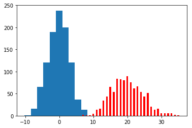

```python
import matplotlib.pyplot as plt
rand_norm = np.random.normal(0., 3., size=1000)  # 정규분포, 평균, 표준편차, 크기
count, bins, ignored = plt.hist(rand_norm, normed=False)

rand_pois = np.random.poisson(lam=20, size=1000)  # 포아송분포, 람다, 크기
unique, counts = np.unique(rand_pois, return_counts=True)
np.asarray((unique, counts)).T
plt.bar(unique, counts, width=.5, color='red', align='center')
```

## 6. Operation function

### 6.1 Sun

```python
test_array = np.arange(1, 11)
print(test_array)
```

```
[ 1  2  3  4  5  6  7  8  9 10]
```

```python
print(test_array.sum(dtype=np.float))
```

```
55.0
```

### 6.2 Axis

- 모든 Operation function을 실행할 때, 기준이 되는 dimension 축
- 1 : → 방향으로 더하기, 각 행의 연산
- 0 : ↓ 방향으로 더하기, 각 열의 연산

```python
test_array = np.arange(1, 13).reshape(3, 4)
print(test_array)
```

```
[[ 1  2  3  4]
 [ 5  6  7  8]
 [ 9 10 11 12]]
```

```python
print(test_array.sum(axis=1))  # → 방향
```

```
[10 26 42]
```

```python
print(test_array.sum(axis=0))  # ↓ 방향
```

```
[15 18 21 24]
```

### 6.3 mean & std

```python
print(test_array)
```

```
[[ 1  2  3  4]
 [ 5  6  7  8]
 [ 9 10 11 12]]
```

```python
print(test_array.mean())  # 전체 평균
```

```
6.5
```

```python
print(test_array.mean(axis=0))  # 각 열의 평균 (↓ 방향)
```

```
[5. 6. 7. 8.]
```

```python
print(test_array.mean(axis=1)) # 각 행의 평균 (→ 방향)
```

```
[ 2.5  6.5 10.5]
```

```python
print(test_array.std())  # 전체 표준편차
```

```
3.452052529534663
```

```python
print(test_array.std(axis=0))  # 각 열의 표준편차
```

```
[3.26598632 3.26598632 3.26598632 3.26598632]
```

### 6.4 Mathematical functions

- 지수함수 : exp, expml, exp2, log, log10, loglp, log2, power, sqrt
- 삼각함수 : sin, cos, tan, arcsin, arccos, arctan
- Hyperbolic : sinh, cosh, tanh, arcsinh, arccosh, arctanh

```python
print(np.exp(test_array))
```

```
[[2.71828183e+00 7.38905610e+00 2.00855369e+01 5.45981500e+01]
 [1.48413159e+02 4.03428793e+02 1.09663316e+03 2.98095799e+03]
 [8.10308393e+03 2.20264658e+04 5.98741417e+04 1.62754791e+05]]
```

```python
print(np.sqrt(test_array))
```

```
[[1.         1.41421356 1.73205081 2.        ]
 [2.23606798 2.44948974 2.64575131 2.82842712]
 [3.         3.16227766 3.31662479 3.46410162]]
```

### 6.5 Concatenate (Numpy array를 합치는 함수)

#### 6.5.1 Vstack = concatenate(axis=0)

```python
a = np.array([[1, 2], [3, 4]])
print(a)
```

```
[[1 2]
 [3 4]]
```

```python
b = np.array([[5, 6]])
print(b)
```

```
[[5 6]]
```

```python
print(np.vstack((a, b)))  # vertical stack  == rbind
```

```
[[1 2]
 [3 4]
 [5 6]]
```

```python
print(np.concatenate((a,b), axis=0)) # 위의 결과와 동일 (axis = 0, 열 방향으로 쌓기)
```

```
[[1 2]
 [3 4]
 [5 6]]
```

#### 6.5.2 Hstack = concatenate(axis=1)

```python
a = np.array([[1], [2], [3]])
print(a)
```

```
[[1]
 [2]
 [3]]
```

```python
b = np.array([[2], [3], [4]])
print(b)
```

```
[[2]
 [3]
 [4]]
```

```python
print(np.hstack((a,b)))  # horizen stack == cbind
```

```
[[1 2]
 [2 3]
 [3 4]]
```

```python
print(np.concatenate((a, b), axis=1))  # 위의 결과와 동일
```

```
[[1 2]
 [2 3]
 [3 4]]
```

#### 6.5.3 Transpose

```python
a = np.array([[1, 2], [3, 4]])
print(a)
```

```
[[1 2]
 [3 4]]
```

```python
b = np.array([[5, 6]])
print(b)
```

```
[[5 6]]
```

```python
print(np.concatenate((a, b.T), axis=1))  # 전치행렬 (b의 행렬을 transpose 시킴)
```

```
[[1 2 5]
 [3 4 6]]
```